# Reproducible Research Assignment 1

JB

August 13, 2014

## Introduction

Personal Tracking devices have gained much attention lately as they enable the user getting insights about his behavioral pattern and help find correlations between acivitity pattern, personal mood, sleep quality, and other indicators. For the current assignment I analyse the data of a tracking device. The variables “date”, “interval” (id of each 5 minute interval thorughout a day) and “steps” (number of steps done during said interval) are analyzed.

## Loading and preprocessing the data

Data are manually downloaded from the course assignment page [here](https://d396qusza40orc.cloudfront.net/repdata%2Fdata%2Factivity.zip) and saved in the project directory. From there it is extracted and loaded into the r environment:

```r
data <- read.csv(unz("activity.zip", "activity.csv"), header=TRUE ,sep=",")
```

### What is mean total number of steps taken per day?

The histogram displays the distirbution pattern of total steps per day over the tracking period. Mean and median steps per day are also calculated:

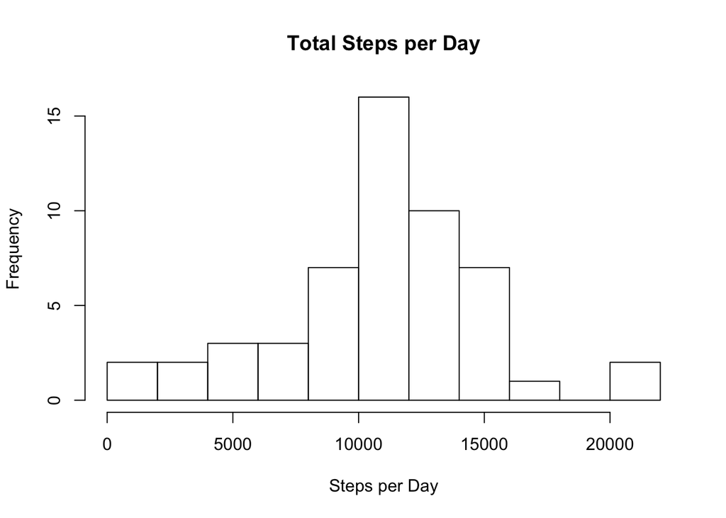

```r
stepsPerDay <- aggregate(steps~date, data=data, FUN=sum, na.action = na.omit)
histStepsPerDay <- hist(stepsPerDay$steps, breaks=15, plot=FALSE)
plot(histStepsPerDay, main="Total Steps per Day", xlab="Steps per Day")
```

```r
mean(stepsPerDay$steps)
```

```
## [1] 10766
```

```r
median(stepsPerDay$steps)
```

```
## [1] 10765
```

### What is the average daily activity pattern?

The average daily activity pattern is displayed as a graph plotting the mean number of steps per interval (over the whole tracking period) vs. the interval id:

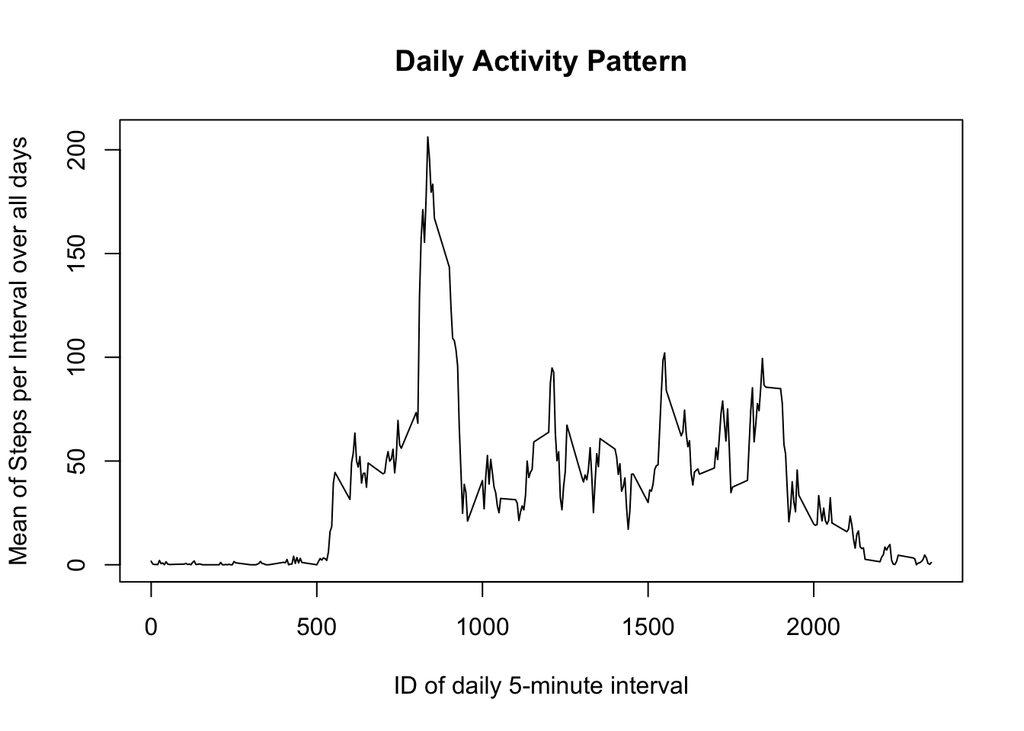

```r
meanStepsPerInterval <- aggregate(steps~interval, data=data, FUN=mean, na.action = na.omit)
plot(steps~interval, data=meanStepsPerInterval, type="l", main="Daily Activity Pattern", ylab="Mean of Steps per Interval over all days", xlab="ID of daily 5-minute interval")
```

```r
# install.packages('sqldf')
library(sqldf)
maxStepsInterval <- sqldf("select interval, max(steps) as steps from meanStepsPerInterval")
maxStepsInterval
```

```
##   interval steps
## 1      835 206.2
```

The interval with on the highest average step count was found to be interval 835 with a step count of 206.1698.

### Imputing missing values

The total number of missing values is calculated as follows:

```r
sum(is.na(data$steps))
```

```
## [1] 2304
```

Since the dataset contains many missing values, they are replaced with the median of steps of the corresponding interval from all days. The corresponding r code has been found [here](http://stackoverflow.com/questions/11971876/how-to-fill-na-with-median).

```r
medianStepsPerInterval <- aggregate(steps~interval, data=data, FUN=median, na.action = na.omit)
dataImputed <- data
dataImputed$steps[is.na(dataImputed$steps)] <-
  medianStepsPerInterval$steps[match(dataImputed$interval, medianStepsPerInterval$interval)][is.na(dataImputed$steps)]

stepsPerDayImputed <- aggregate(steps~date, data=dataImputed, FUN=sum, na.action = na.omit)
```

The following histogram overlays the original data (containing many missing values) with the data set in which missing values where replaced.

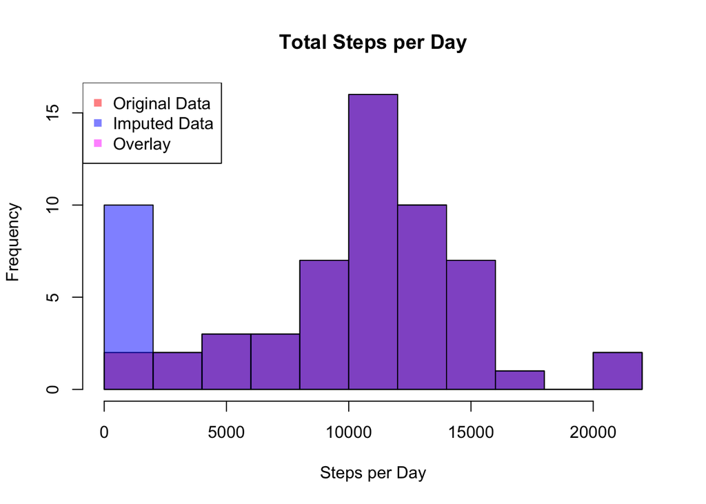

```r
histStepsPerDayImputed <- hist(stepsPerDayImputed$steps, breaks=15, plot=FALSE)

colors = c(rgb(1,0,0,1/2), rgb(0,0,1,1/2))
plot(histStepsPerDay, col=colors[1], main="Total Steps per Day", xlab="Steps per Day")
plot(histStepsPerDayImputed, col=colors[2], add=TRUE)
legend(x="topleft", legend=c("Original Data", "Imputed Data", "Overlay"), pch=15, col=append(colors, rgb(1,0,1,1/2)))
```

```r
mean(stepsPerDayImputed$steps)
```

```
## [1] 9504
```

```r
median(stepsPerDayImputed$steps)
```

```
## [1] 10395
```

Missing values have mostly been replaced with small numbers, as identified in the histogram: the first (most left) bin increased from ca. 2 to ca. 10 after data replacement. Mean number of total daily steps has drastically decreased from 1.0766 × 10<sup>4</sup> to 9503.8689, whereas the median has only changed from 10765 to 10395. Mean is prune to outliers (like 0), median is not. As shown in the histogram, this difference in change between mean and median can be attributed to the fact that missing values have been replaced by small values, i.e. missing data mostly occur during periods in which activity (step count) is usually low.

The following plot indicates when (during which 5 minute interval) missing data occurred:

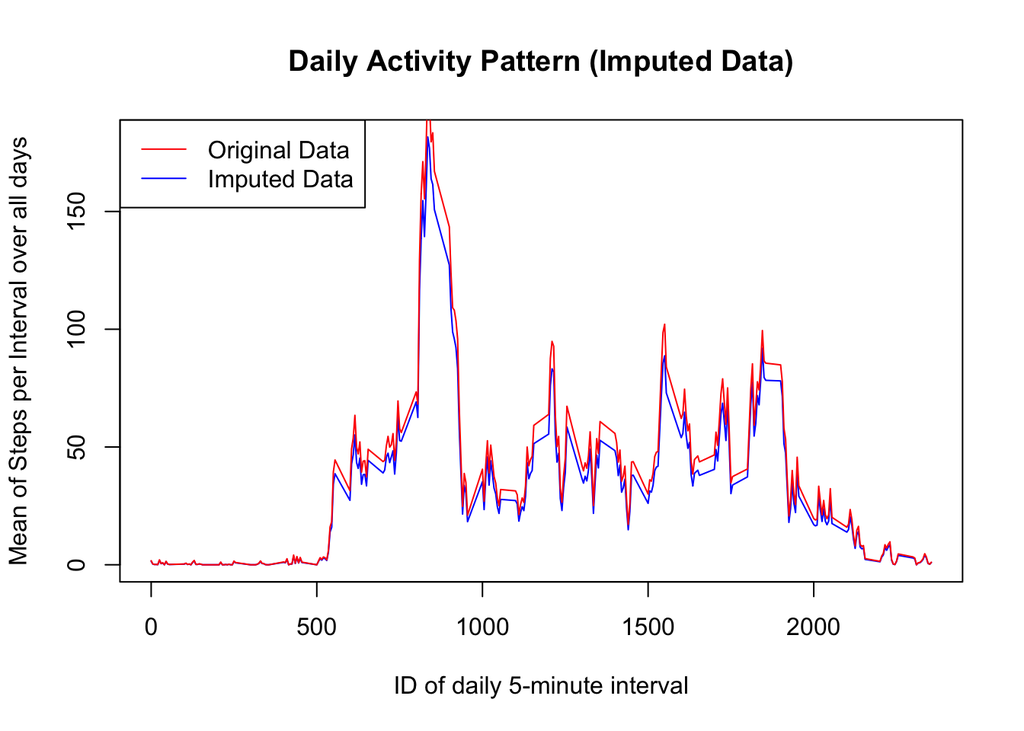

```r
meanStepsPerIntervalImputed <- aggregate(steps~interval, data=dataImputed, FUN=mean, na.action = na.omit)
plot(steps~interval, data=meanStepsPerIntervalImputed, type="l", main="Daily Activity Pattern (Imputed Data)", ylab="Mean of Steps per Interval over all days", xlab="ID of daily 5-minute interval", col="blue")
lines(steps~interval, data=meanStepsPerInterval, col="red")
legend(x="topleft", legend=c("Original Data", "Imputed Data"), lty=c(1,1), col=c("red", "blue"))
```

Cleary, missing data occurred throughout the day. The replacement of missing data lead to lower total number of steps per interval, averaged over all days.

### Are there differences in activity patterns between weekdays and weekends?

To assess whether activity pattern differs between weekdays and weekends, a new factor variable “daytype” with factors “weekend” and “weekday” is introduced, and activity pattern per day type is plotted:

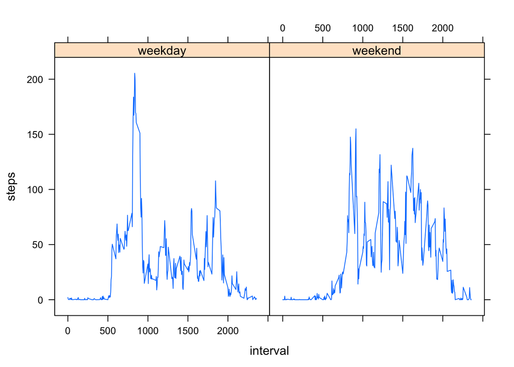

```r
dataImputed$weekend <- weekdays(as.POSIXlt(dataImputed$date)) %in% c('Sunday','Saturday', 'Samstag', 'Sonntag')
# count(dataImputed$weekend)

dataImputed$weekend[dataImputed$weekend==TRUE] <- "weekend"
dataImputed$weekend[dataImputed$weekend==FALSE] <- "weekday"
dataImputed$dayType <- factor(dataImputed$weekend)
dataImputed$weekend <- NULL

meanStepsPerDayType <- aggregate(steps~interval+dayType, data=dataImputed, FUN=mean)
library(lattice)
xyplot(steps ~ interval | dayType, data=meanStepsPerDayType, type="l", as.table=TRUE)
```

On weekdays, peak activity is higher and activity start is earlier than on weekends. On weekends, though, activity seems to be generally more uniform throughout the day.